# LAPD_bias_investigation

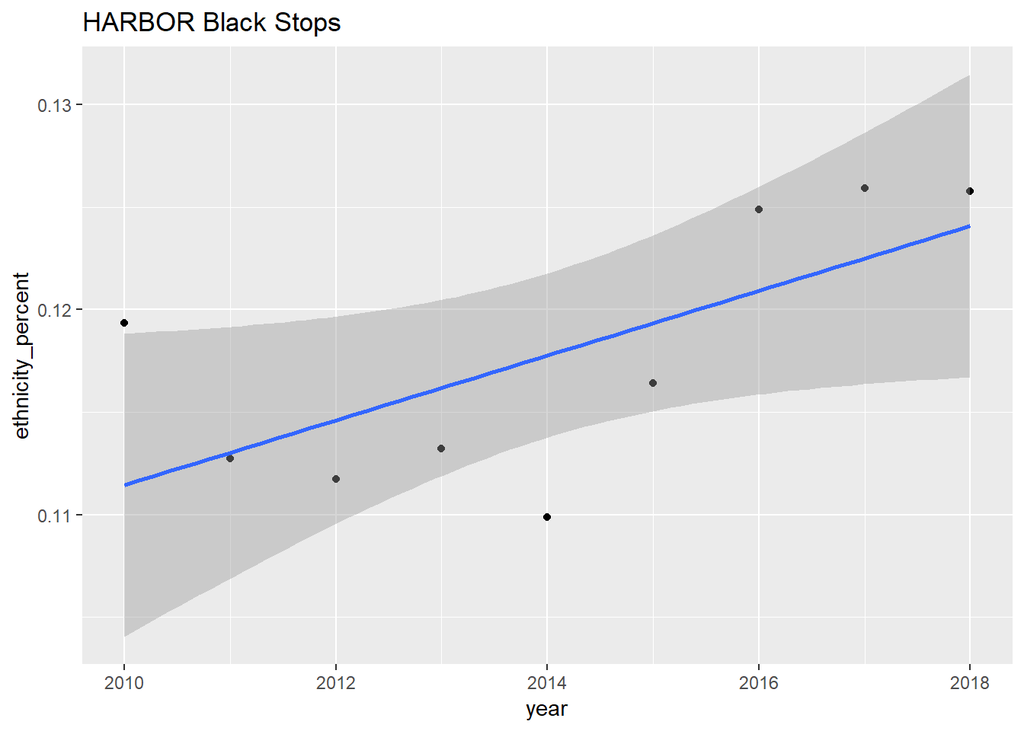

```
##
## Call:
## lm(formula = ethnicity_percent ~ year, data = filter(stops_summary_by_year_with_pop,
##     division == div, ethnicity == "BLACK", location == "stops"))
##
## Residuals:
##       Min        1Q    Median        3Q       Max
## -0.008945 -0.003046 -0.001160  0.001260  0.009995
##
## Coefficients:
##               Estimate Std. Error t value Pr(>|t|)
## (Intercept) -4.6451263  1.3950180  -3.330  0.01039 *
## year         0.0023654  0.0006925   3.416  0.00914 **
## ---
## Signif. codes:  0 '***' 0.001 '**' 0.01 '*' 0.05 '.' 0.1 ' ' 1
##
## Residual standard error: 0.00629 on 8 degrees of freedom
## Multiple R-squared:  0.5932, Adjusted R-squared:  0.5424
## F-statistic: 11.67 on 1 and 8 DF,  p-value: 0.009144
```

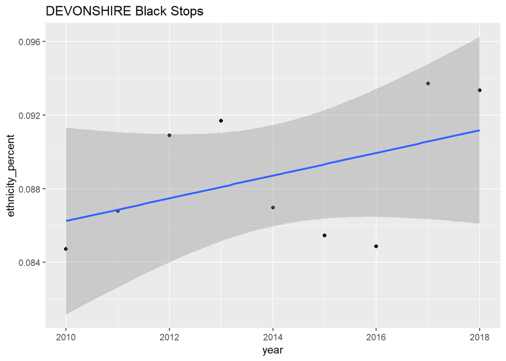

```
##
## Call:
## lm(formula = ethnicity_percent ~ year, data = filter(stops_summary_by_year_with_pop,
##     division == div, ethnicity == "BLACK", location == "stops"))
##
## Residuals:
##        Min         1Q     Median         3Q        Max
## -0.0064890 -0.0018246  0.0002621  0.0029091  0.0050826
##
## Coefficients:
##               Estimate Std. Error t value Pr(>|t|)
## (Intercept) -2.0058466  0.8758288  -2.290   0.0512 .
## year         0.0010403  0.0004348   2.393   0.0437 *
## ---
## Signif. codes:  0 '***' 0.001 '**' 0.01 '*' 0.05 '.' 0.1 ' ' 1
##
## Residual standard error: 0.003949 on 8 degrees of freedom
## Multiple R-squared:  0.4171, Adjusted R-squared:  0.3443
## F-statistic: 5.725 on 1 and 8 DF,  p-value: 0.04367
```

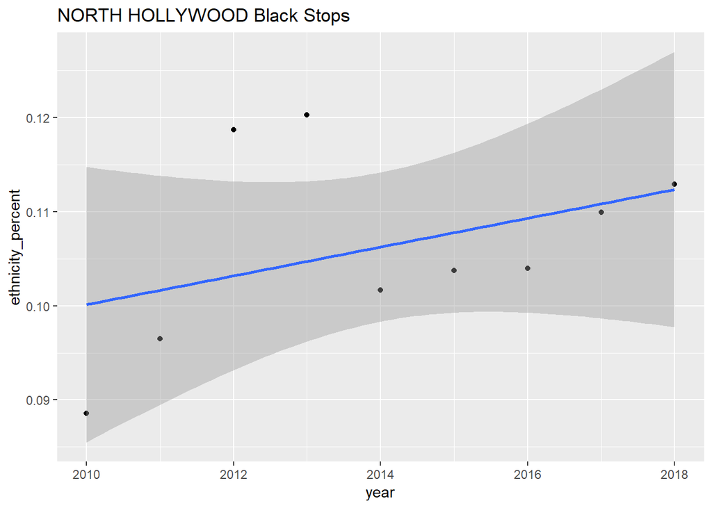

```
##
## Call:
## lm(formula = ethnicity_percent ~ year, data = filter(stops_summary_by_year_with_pop,
##     division == div, ethnicity == "BLACK", location == "stops"))
##
## Residuals:
##       Min        1Q    Median        3Q       Max
## -0.009701 -0.006967 -0.006377  0.010593  0.016382
##
## Coefficients:
##              Estimate Std. Error t value Pr(>|t|)
## (Intercept) -5.608086   2.584803  -2.170   0.0619 .
## year         0.002838   0.001283   2.212   0.0579 .
## ---
## Signif. codes:  0 '***' 0.001 '**' 0.01 '*' 0.05 '.' 0.1 ' ' 1
##
## Residual standard error: 0.01165 on 8 degrees of freedom
## Multiple R-squared:  0.3795, Adjusted R-squared:  0.3019
## F-statistic: 4.893 on 1 and 8 DF,  p-value: 0.0579
```

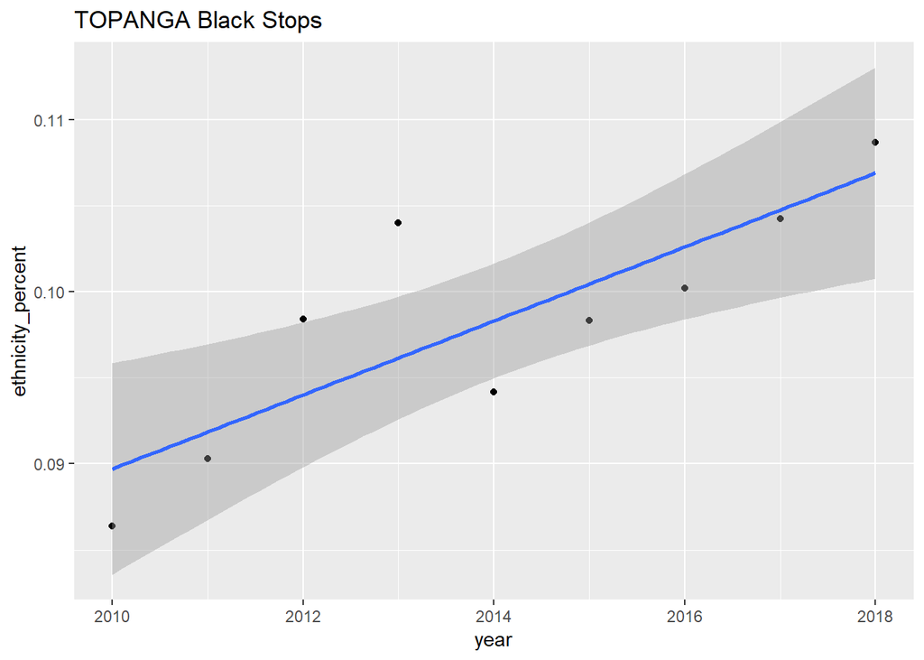

```
##
## Call:
## lm(formula = ethnicity_percent ~ year, data = filter(stops_summary_by_year_with_pop,
##     division == div, ethnicity == "BLACK", location == "stops"))
##
## Residuals:
##       Min        1Q    Median        3Q       Max
## -0.003964 -0.001948 -0.001592  0.001801  0.007894
##
## Coefficients:
##               Estimate Std. Error t value Pr(>|t|)
## (Intercept) -3.9910180  0.8878770  -4.495  0.00202 **
## year         0.0020304  0.0004407   4.607  0.00174 **
## ---
## Signif. codes:  0 '***' 0.001 '**' 0.01 '*' 0.05 '.' 0.1 ' ' 1
##
## Residual standard error: 0.004003 on 8 degrees of freedom
## Multiple R-squared:  0.7262, Adjusted R-squared:  0.692
## F-statistic: 21.22 on 1 and 8 DF,  p-value: 0.00174
```

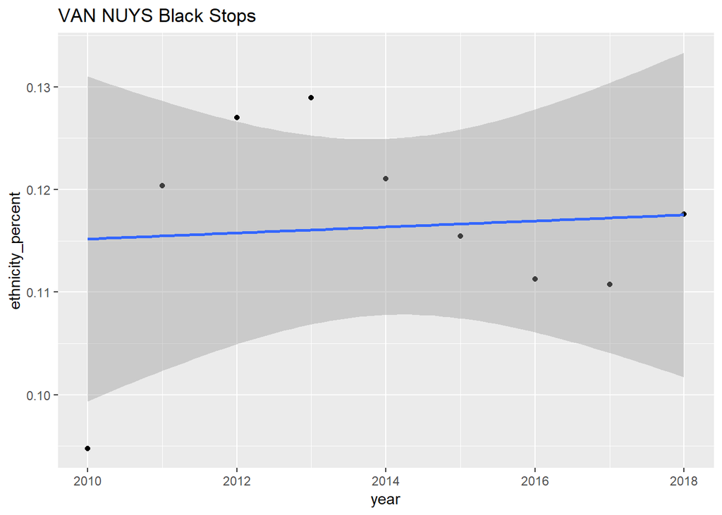

```
##
## Call:
## lm(formula = ethnicity_percent ~ year, data = filter(stops_summary_by_year_with_pop,
##     division == div, ethnicity == "BLACK", location == "stops"))
##
## Residuals:
##       Min        1Q    Median        3Q       Max
## -0.019552 -0.005537  0.001109  0.005127  0.012767
##
## Coefficients:
##               Estimate Std. Error t value Pr(>|t|)
## (Intercept) -1.1169921  2.2888624  -0.488    0.639
## year         0.0006126  0.0011362   0.539    0.604
##
## Residual standard error: 0.01032 on 8 degrees of freedom
## Multiple R-squared:  0.03506,    Adjusted R-squared:  -0.08555
## F-statistic: 0.2907 on 1 and 8 DF,  p-value: 0.6044
```

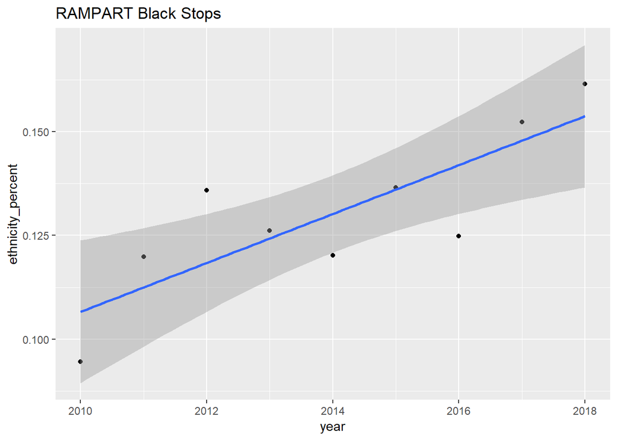

```
##
## Call:
## lm(formula = ethnicity_percent ~ year, data = filter(stops_summary_by_year_with_pop,
##     division == div, ethnicity == "BLACK", location == "stops"))
##
## Residuals:
##       Min        1Q    Median        3Q       Max
## -0.017876 -0.007719  0.002253  0.005716  0.017600
##
## Coefficients:
##               Estimate Std. Error t value Pr(>|t|)
## (Intercept) -12.198667   2.467032  -4.945  0.00113 **
## year          0.006122   0.001225   4.999  0.00105 **
## ---
## Signif. codes:  0 '***' 0.001 '**' 0.01 '*' 0.05 '.' 0.1 ' ' 1
##
## Residual standard error: 0.01112 on 8 degrees of freedom
## Multiple R-squared:  0.7575, Adjusted R-squared:  0.7272
## F-statistic: 24.99 on 1 and 8 DF,  p-value: 0.001054
```

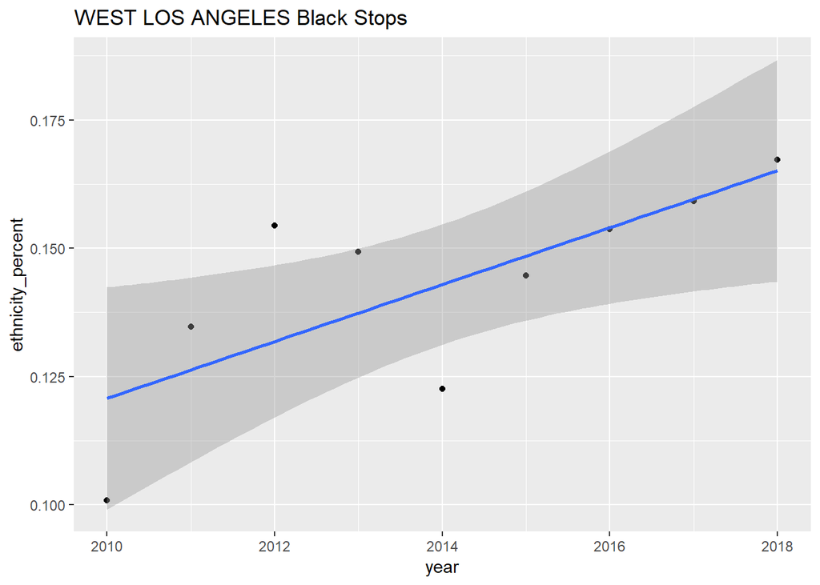

```
##
## Call:
## lm(formula = ethnicity_percent ~ year, data = filter(stops_summary_by_year_with_pop,
##     division == div, ethnicity == "BLACK", location == "stops"))
##
## Residuals:
##       Min        1Q    Median        3Q       Max
## -0.023091 -0.011040  0.004176  0.007972  0.021725
##
## Coefficients:
##              Estimate Std. Error t value Pr(>|t|)
## (Intercept) -8.614714   3.387334  -2.543   0.0345 *
## year         0.004348   0.001681   2.586   0.0323 *
## ---
## Signif. codes:  0 '***' 0.001 '**' 0.01 '*' 0.05 '.' 0.1 ' ' 1
##
## Residual standard error: 0.01527 on 8 degrees of freedom
## Multiple R-squared:  0.4552, Adjusted R-squared:  0.3871
## F-statistic: 6.685 on 1 and 8 DF,  p-value: 0.03233
```

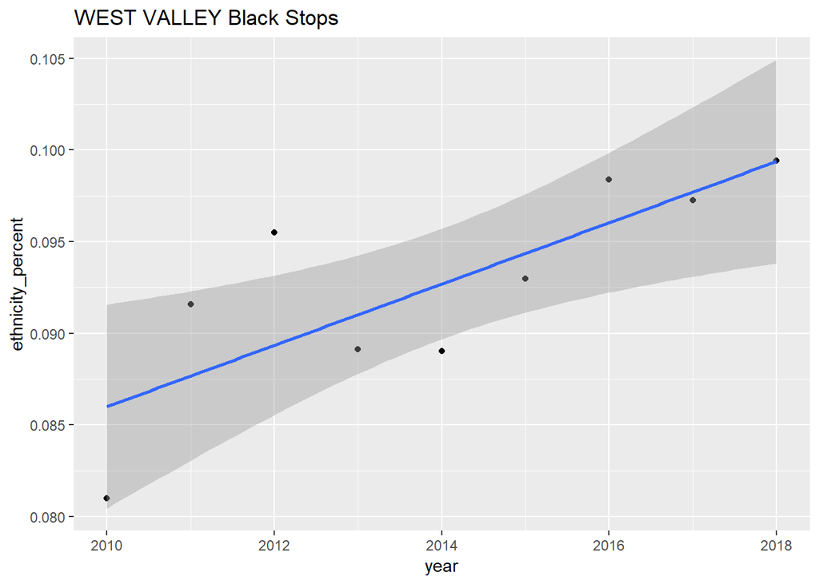

```
##
## Call:
## lm(formula = ethnicity_percent ~ year, data = filter(stops_summary_by_year_with_pop,
##     division == div, ethnicity == "BLACK", location == "stops"))
##
## Residuals:
##        Min         1Q     Median         3Q        Max
## -0.0054682 -0.0020482 -0.0003331  0.0024468  0.0060165
##
## Coefficients:
##               Estimate Std. Error t value Pr(>|t|)
## (Intercept) -2.9186551  0.8195884  -3.561  0.00739 **
## year         0.0014951  0.0004068   3.675  0.00627 **
## ---
## Signif. codes:  0 '***' 0.001 '**' 0.01 '*' 0.05 '.' 0.1 ' ' 1
##
## Residual standard error: 0.003695 on 8 degrees of freedom
## Multiple R-squared:  0.628,  Adjusted R-squared:  0.5815
## F-statistic:  13.5 on 1 and 8 DF,  p-value: 0.006265
```

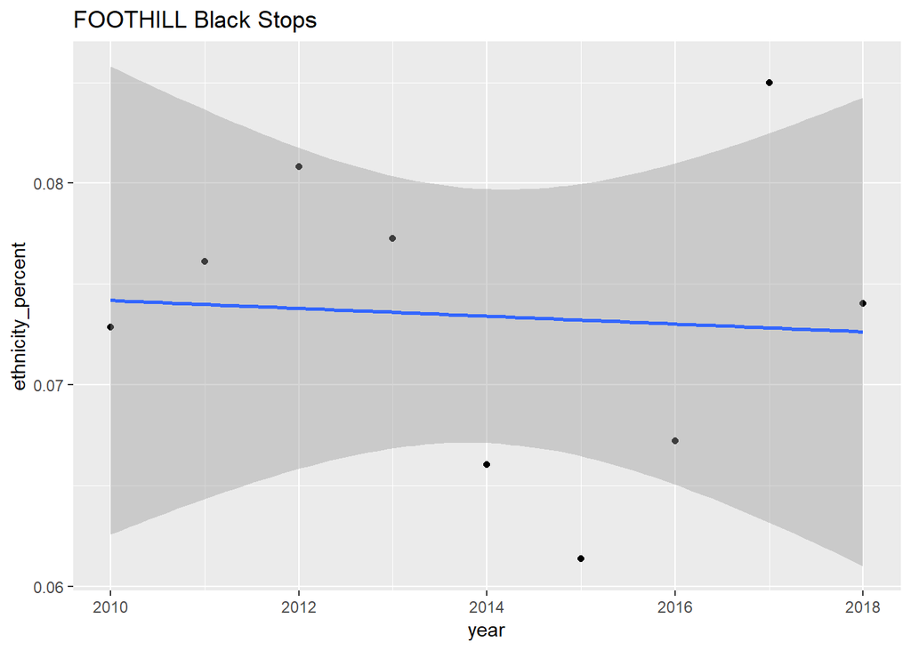

```
##
## Call:
## lm(formula = ethnicity_percent ~ year, data = filter(stops_summary_by_year_with_pop,
##     division == div, ethnicity == "BLACK", location == "stops"))
##
## Residuals:
##        Min         1Q     Median         3Q        Max
## -0.0104808 -0.0059185 -0.0008745  0.0043583  0.0147072
##
## Coefficients:
##               Estimate Std. Error t value Pr(>|t|)
## (Intercept)  1.6404881  1.7928973   0.915    0.387
## year        -0.0007785  0.0008900  -0.875    0.407
##
## Residual standard error: 0.008084 on 8 degrees of freedom
## Multiple R-squared:  0.08729,    Adjusted R-squared:  -0.0268
## F-statistic: 0.7651 on 1 and 8 DF,  p-value: 0.4072
```

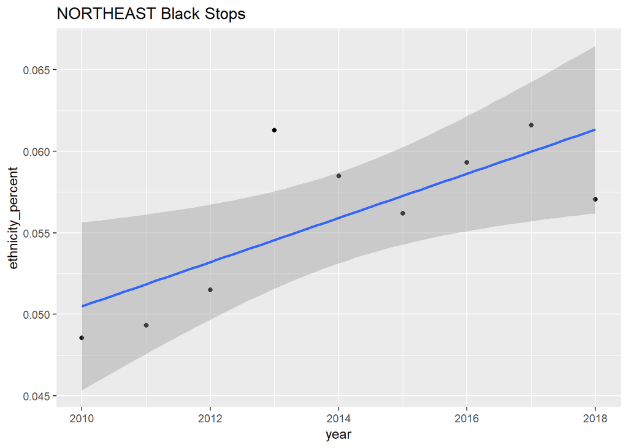

```
##
## Call:
## lm(formula = ethnicity_percent ~ year, data = filter(stops_summary_by_year_with_pop,
##     division == div, ethnicity == "BLACK", location == "stops"))
##
## Residuals:
##       Min        1Q    Median        3Q       Max
## -0.003650 -0.002160 -0.001139  0.001879  0.006754
##
## Coefficients:
##              Estimate Std. Error t value Pr(>|t|)
## (Intercept) -2.427613   0.747364  -3.248   0.0117 *
## year         0.001233   0.000371   3.324   0.0105 *
## ---
## Signif. codes:  0 '***' 0.001 '**' 0.01 '*' 0.05 '.' 0.1 ' ' 1
##
## Residual standard error: 0.00337 on 8 degrees of freedom
## Multiple R-squared:   0.58,  Adjusted R-squared:  0.5275
## F-statistic: 11.05 on 1 and 8 DF,  p-value: 0.01048
```

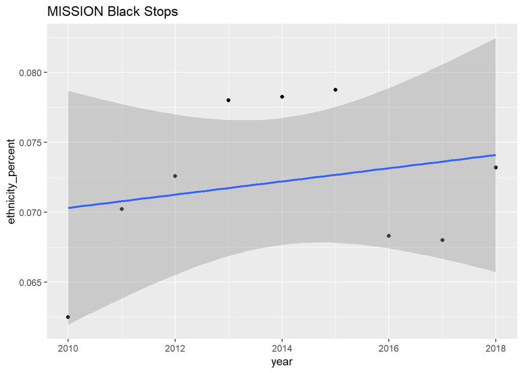

```
##
## Call:
## lm(formula = ethnicity_percent ~ year, data = filter(stops_summary_by_year_with_pop,
##     division == div, ethnicity == "BLACK", location == "stops"))
##
## Residuals:
##        Min         1Q     Median         3Q        Max
## -0.0079373 -0.0036845 -0.0005738  0.0048990  0.0062870
##
## Coefficients:
##               Estimate Std. Error t value Pr(>|t|)
## (Intercept) -0.7918976  1.1948136  -0.663    0.526
## year         0.0004290  0.0005931   0.723    0.490
##
## Residual standard error: 0.005387 on 8 degrees of freedom
## Multiple R-squared:  0.06139,    Adjusted R-squared:  -0.05594
## F-statistic: 0.5232 on 1 and 8 DF,  p-value: 0.4901
```

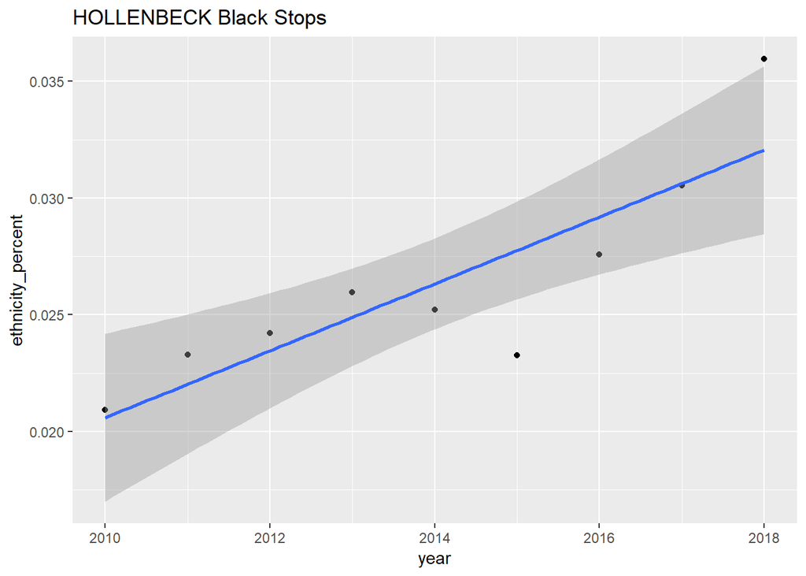

```
##
## Call:
## lm(formula = ethnicity_percent ~ year, data = filter(stops_summary_by_year_with_pop,
##     division == div, ethnicity == "BLACK", location == "stops"))
##
## Residuals:
##        Min         1Q     Median         3Q        Max
## -0.0043114 -0.0009953  0.0001945  0.0009876  0.0043466
##
## Coefficients:
##              Estimate Std. Error t value Pr(>|t|)
## (Intercept) -2.693933   0.521791  -5.163 0.000861 ***
## year         0.001351   0.000259   5.214 0.000808 ***
## ---
## Signif. codes:  0 '***' 0.001 '**' 0.01 '*' 0.05 '.' 0.1 ' ' 1
##
## Residual standard error: 0.002353 on 8 degrees of freedom
## Multiple R-squared:  0.7727, Adjusted R-squared:  0.7442
## F-statistic: 27.19 on 1 and 8 DF,  p-value: 0.0008081
```

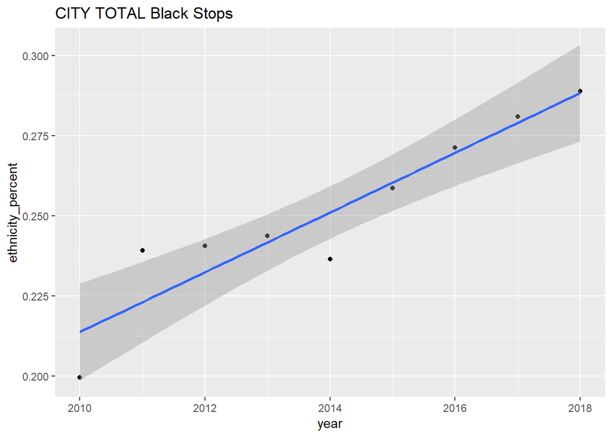

```
##
## Call:
## lm(formula = ethnicity_percent ~ year, data = filter(stops_summary_by_year_with_pop,
##     division == div, ethnicity == "BLACK", location == "stops"))
##
## Residuals:
##       Min        1Q    Median        3Q       Max
## -0.017928 -0.009218  0.004356  0.007771  0.013809
##
## Coefficients:
##               Estimate Std. Error t value Pr(>|t|)
## (Intercept) -15.750160   2.687029  -5.862 0.000378 ***
## year          0.007944   0.001334   5.956 0.000340 ***
## ---
## Signif. codes:  0 '***' 0.001 '**' 0.01 '*' 0.05 '.' 0.1 ' ' 1
##
## Residual standard error: 0.01212 on 8 degrees of freedom
## Multiple R-squared:  0.816,  Adjusted R-squared:  0.793
## F-statistic: 35.47 on 1 and 8 DF,  p-value: 0.0003398
```

### Yearly black stops by division

For each year in our data set, plot the black population verses the number of black stops for each division.

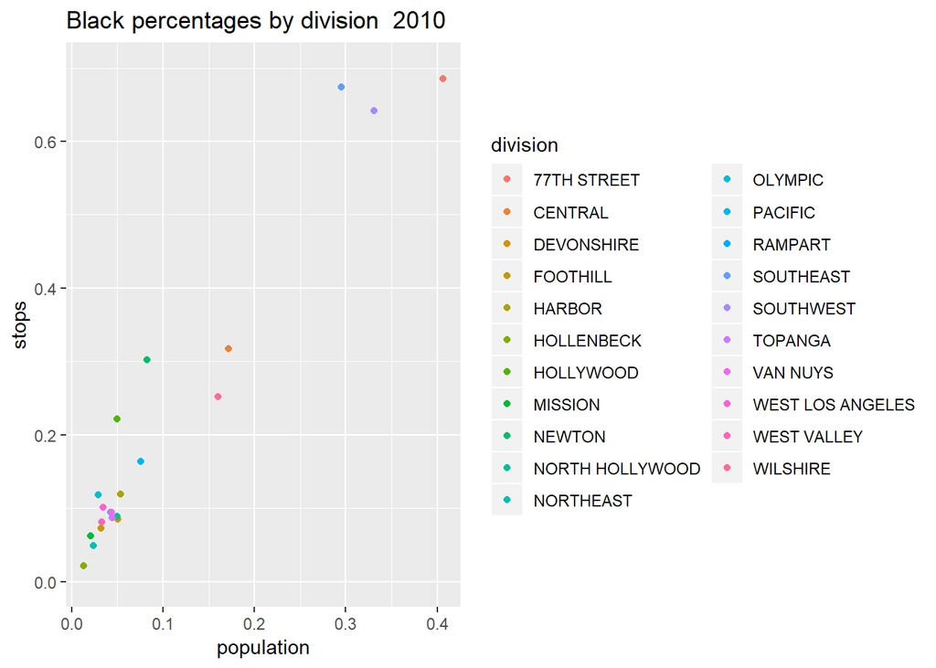

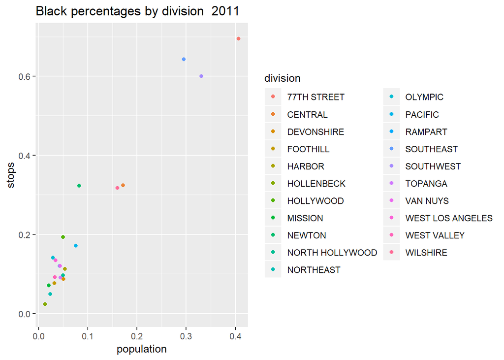

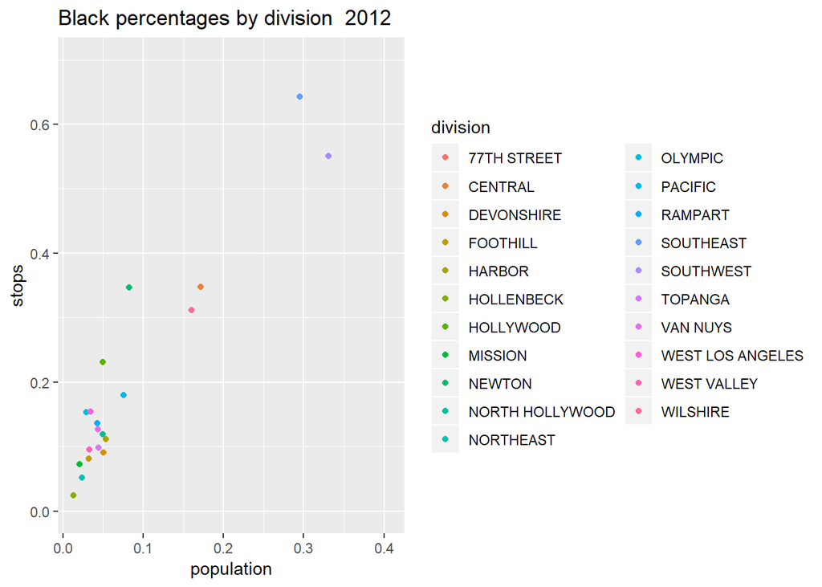

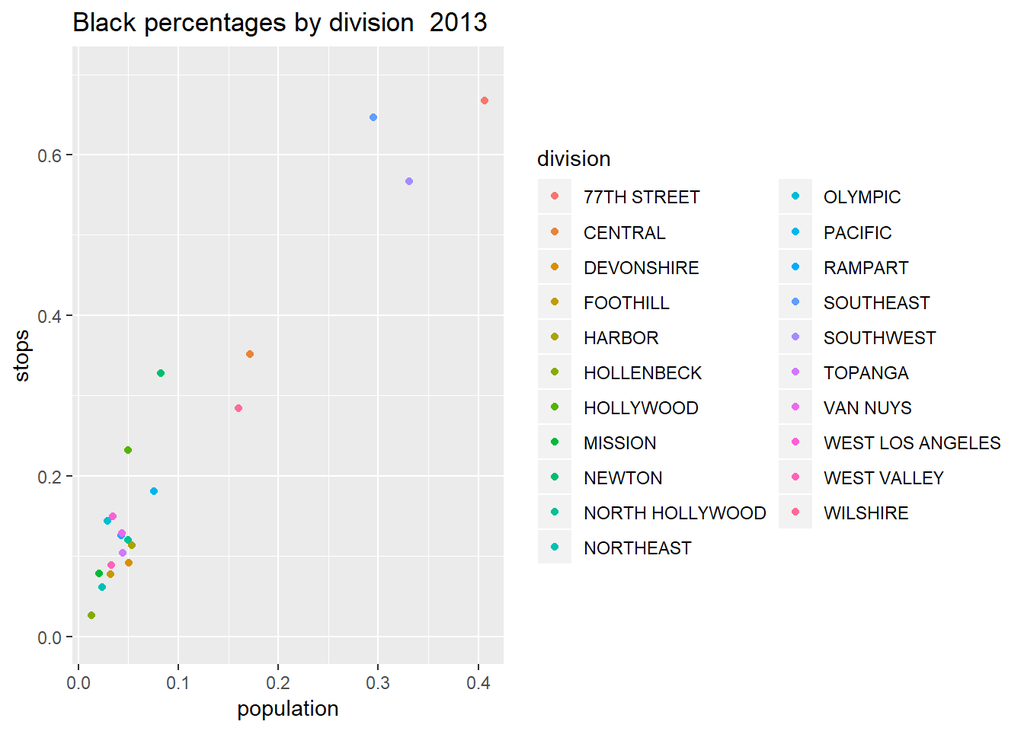

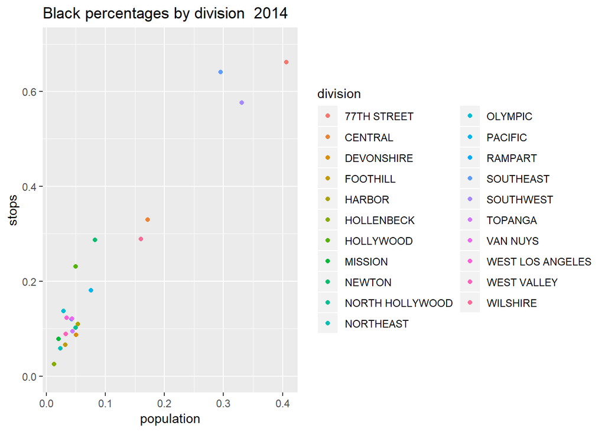

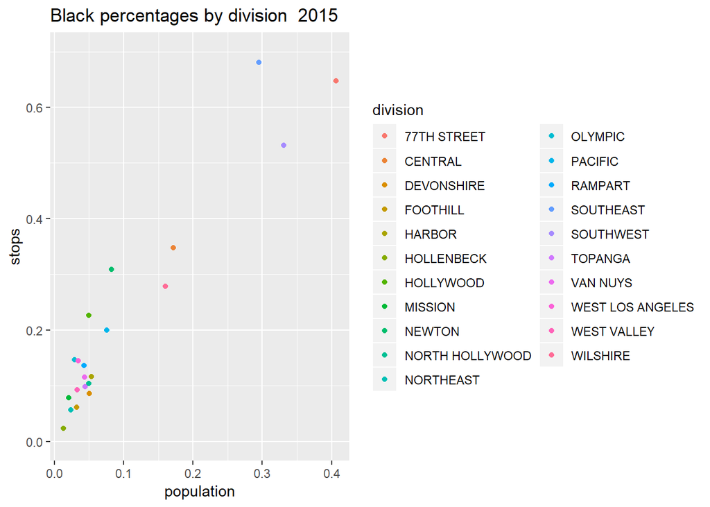

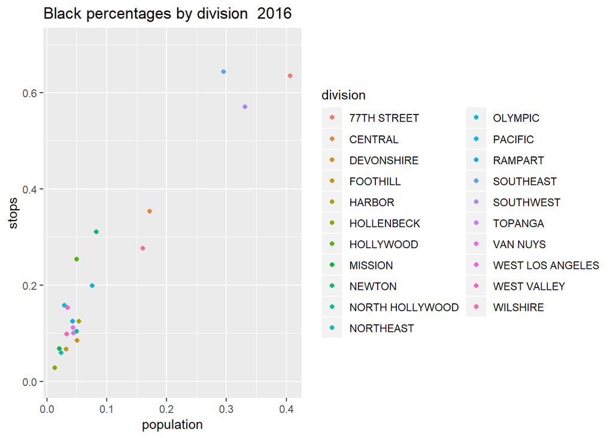

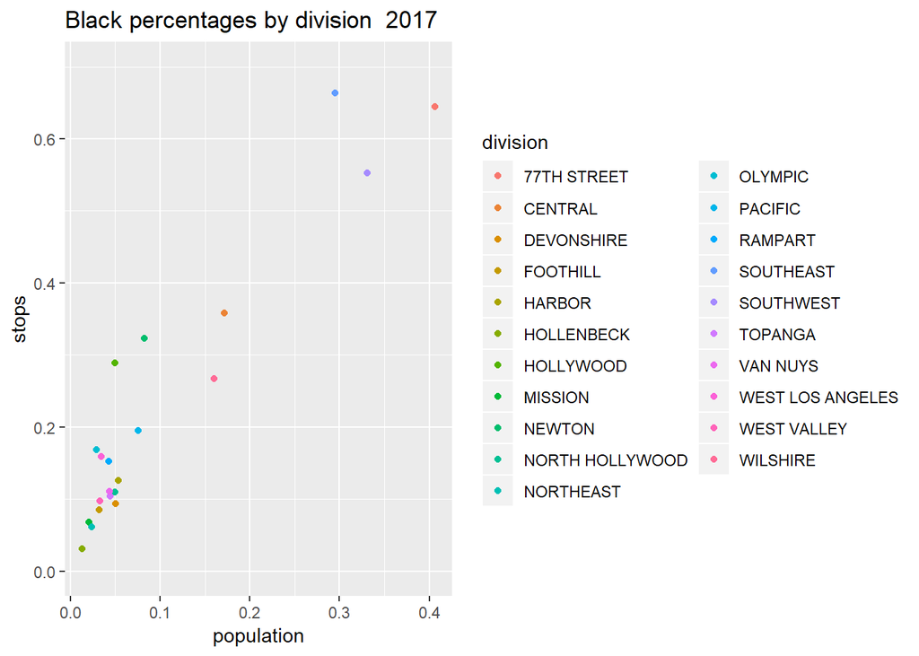

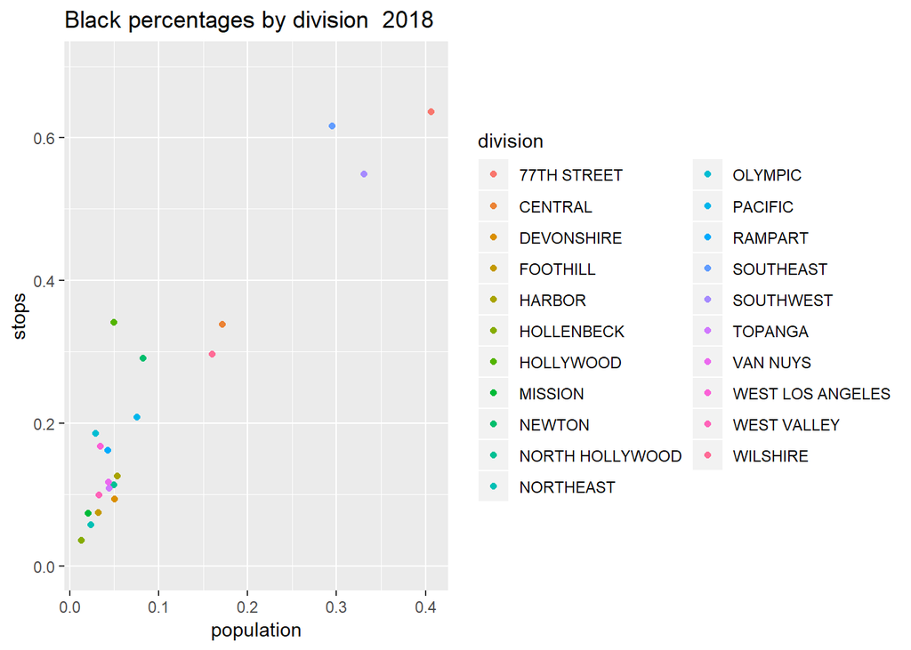

###Black percentages and counts 2018 Plot the black population verses the number of black stops for each division in 2018. Then plot the population percentage verses stops percentage by division for blacks, also in 2018.

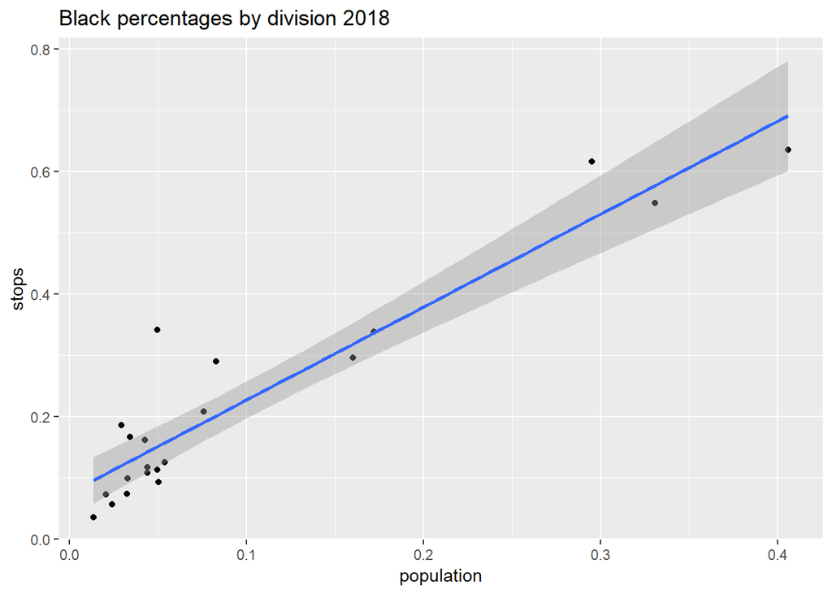

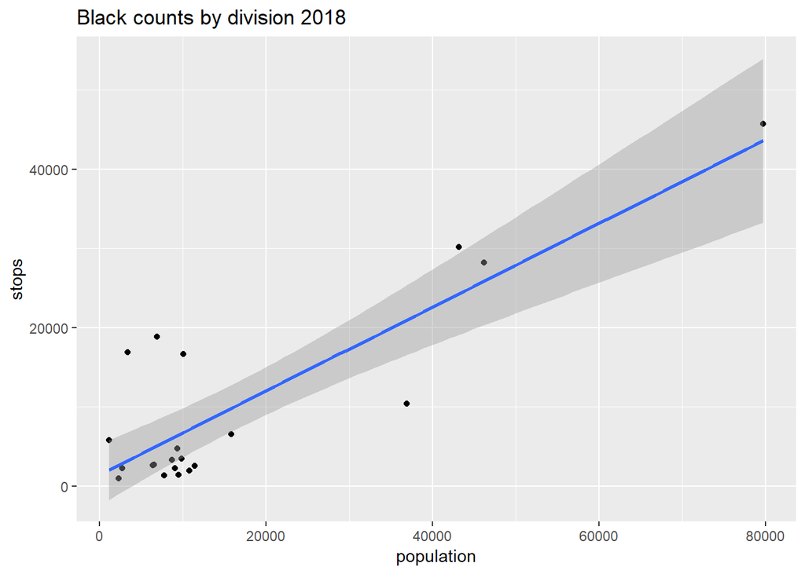

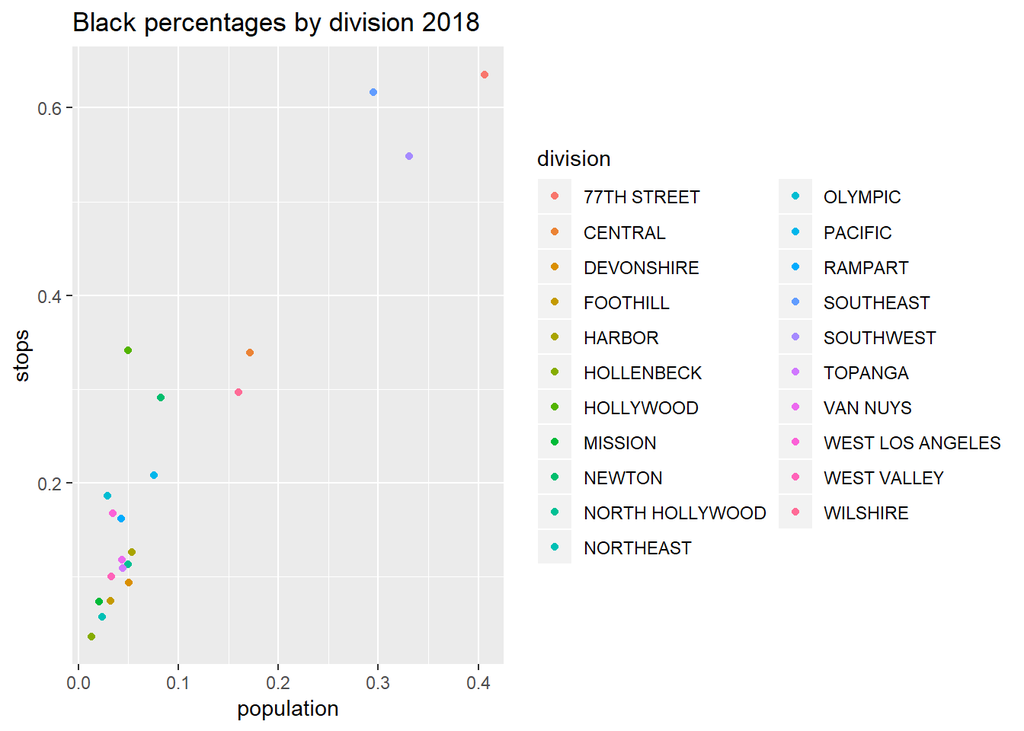

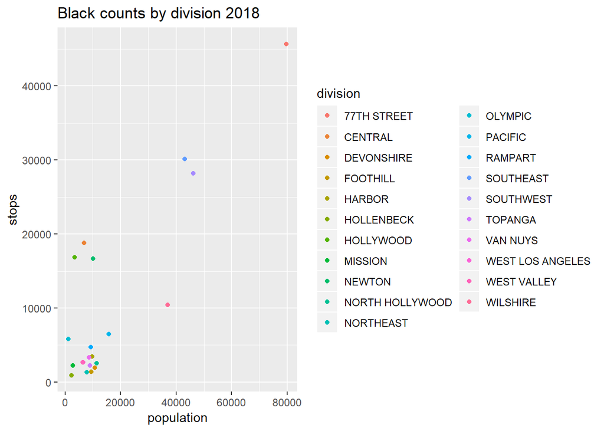

### Ethnicity distributions 2018 - problem divisions

Divisions to focus on: * Southeast - it’s above both the percent and count trend lines * Central - it’s on the percent line but way above the count line due to very large ratio of stops to population * Newton - it’s above both the percent and count trend lines * Hollywood -it’s above both the percent and count trend lines * Olympic - it’s above both the percent and count trend lines * West Los Angeles - it’s above the percent trend line

Graph the ethnicity breakdown for each of the problem divisions

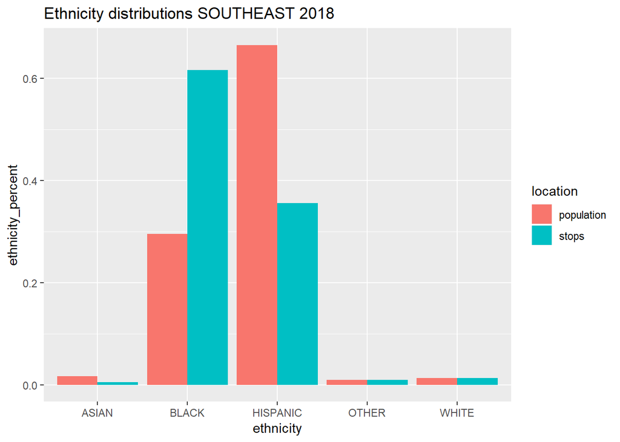

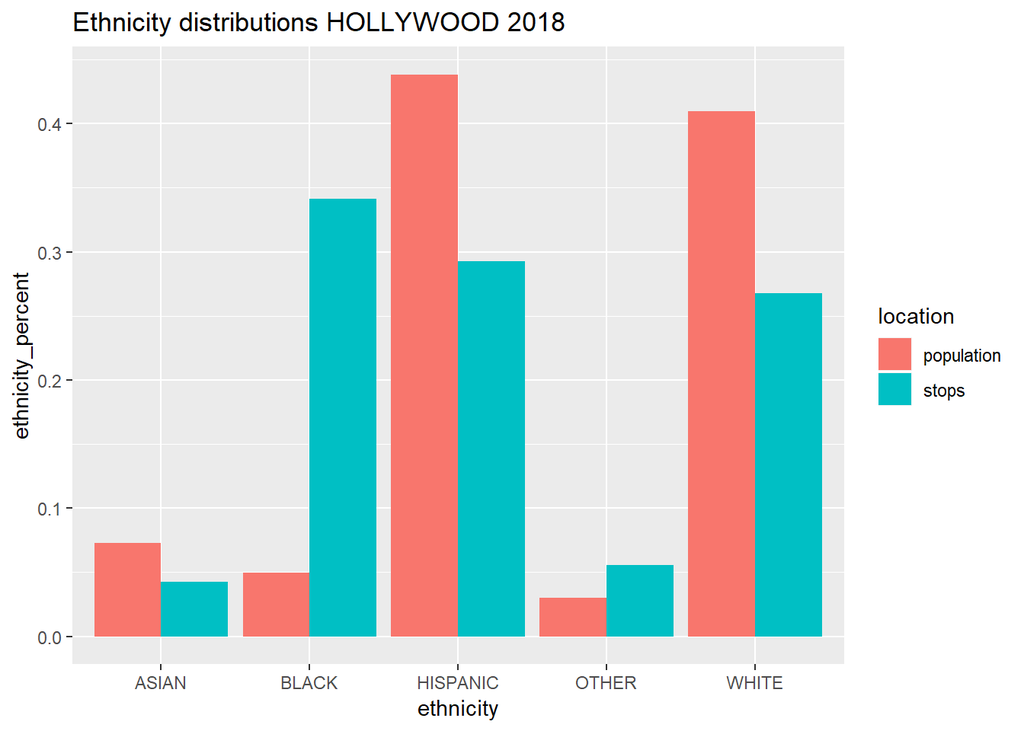

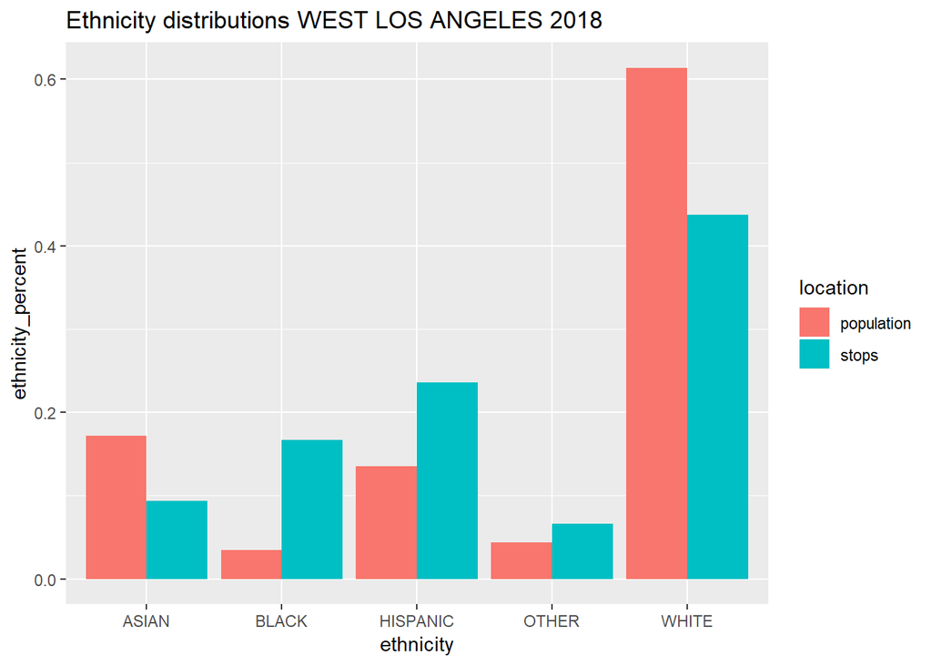

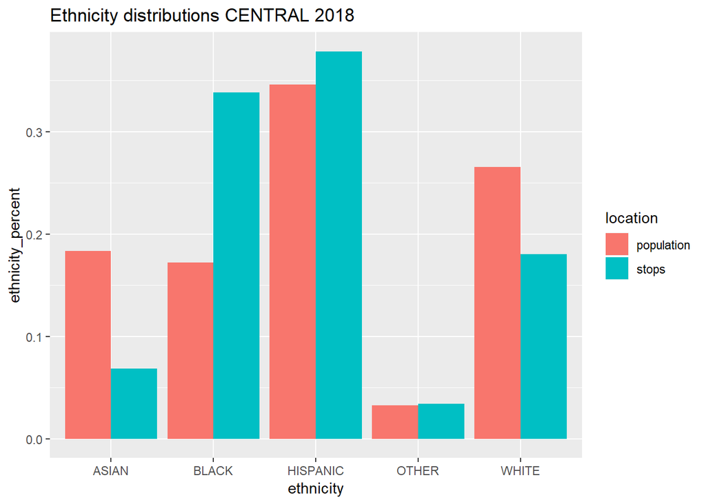

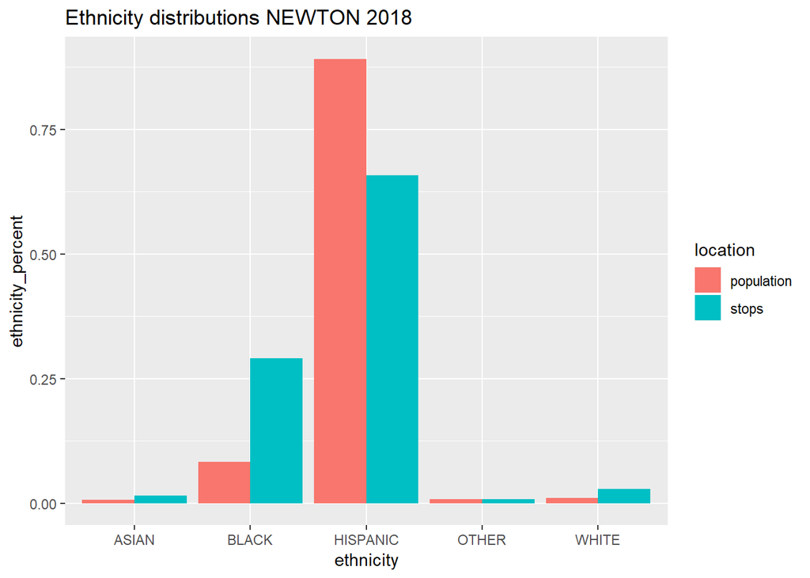

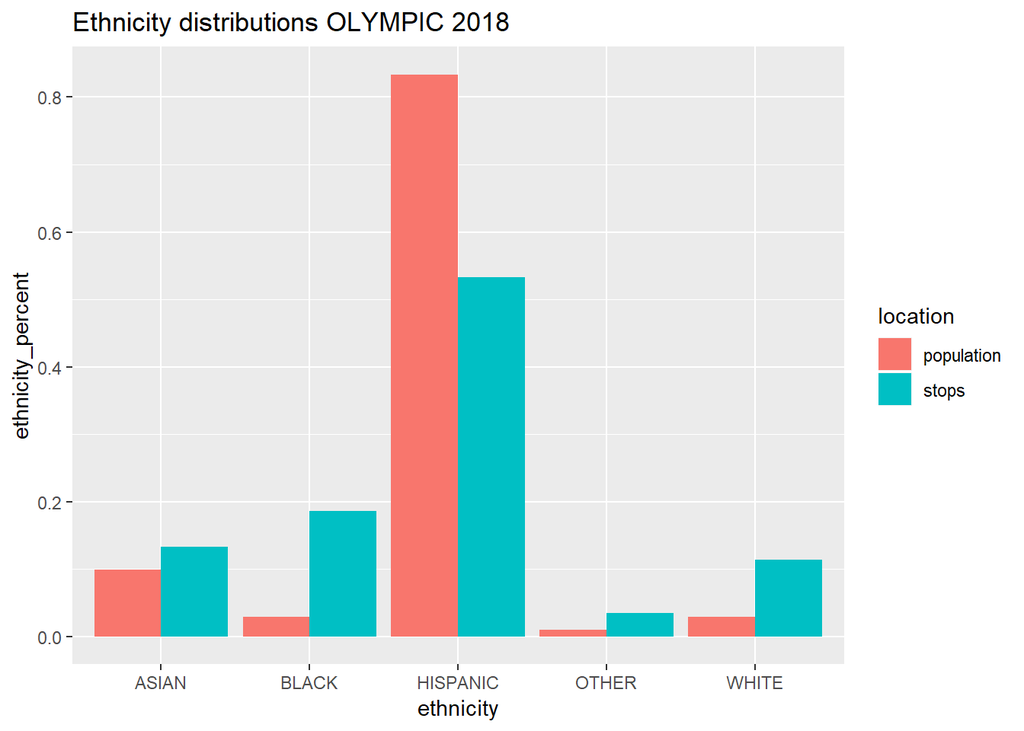

### Officers in problem divisions

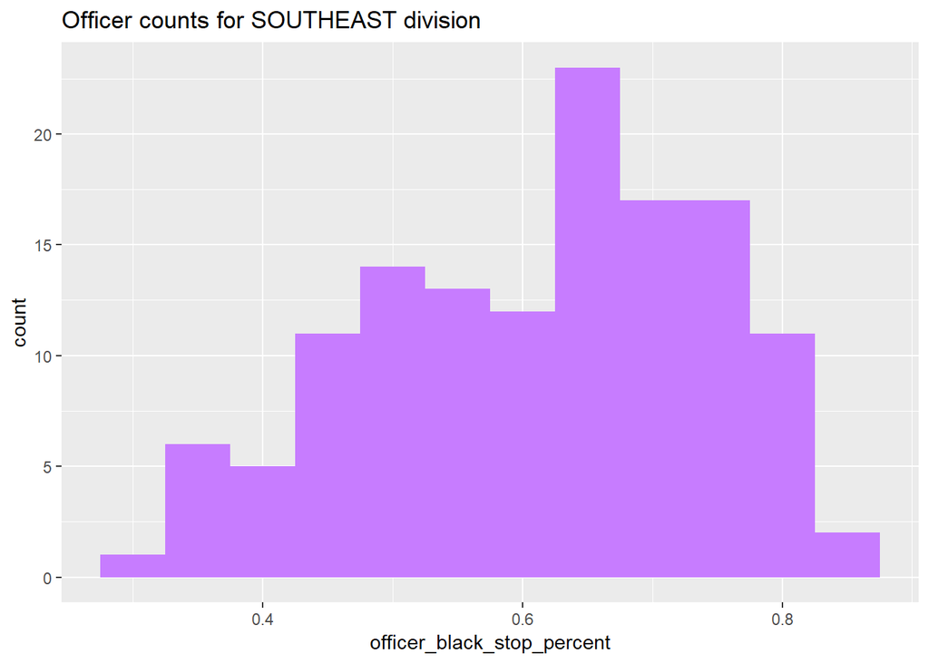

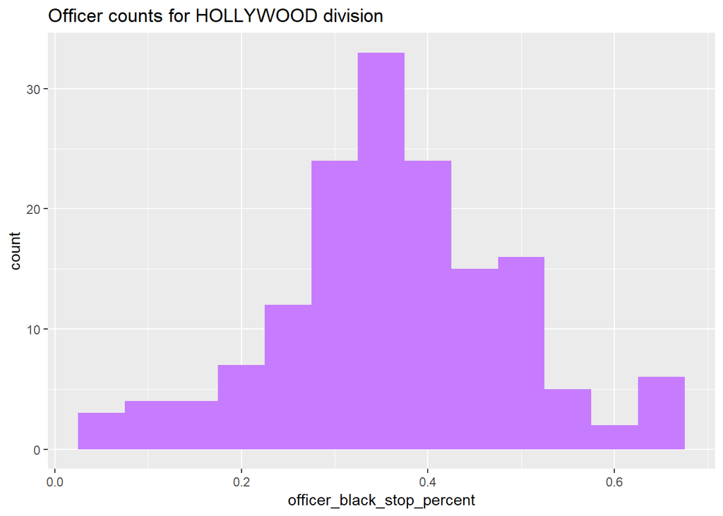

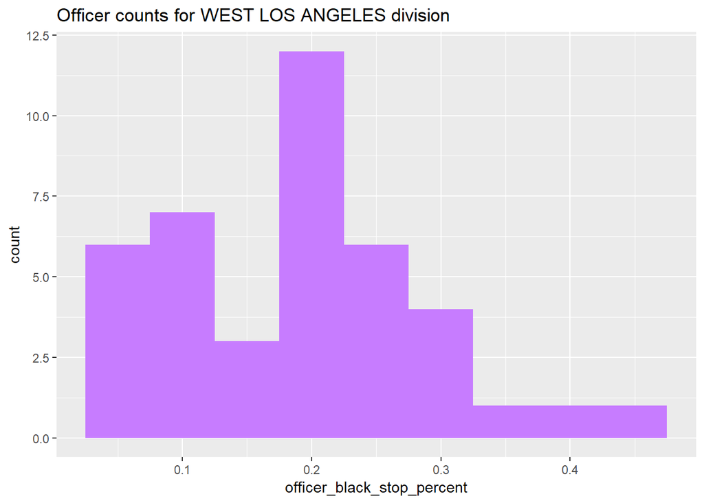

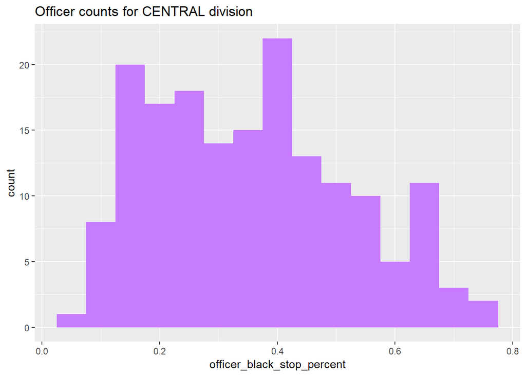

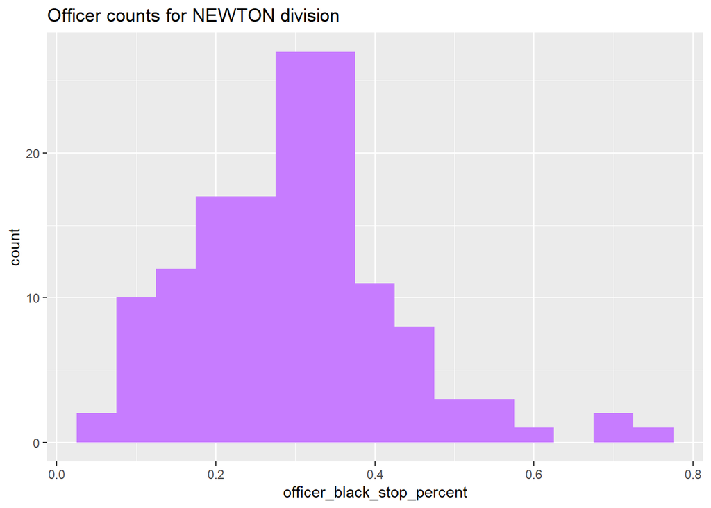

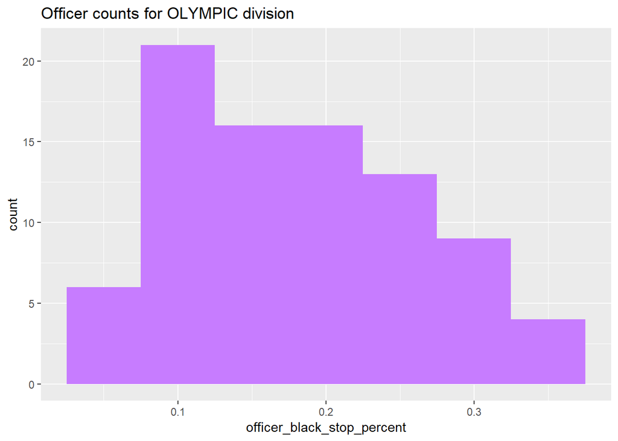

### Identify officers for anti-bias training

Identify officers to recommened for anti-bias training. Thresholds for officer_black_stop_percent were determined by looking at the histograms and finding a good cutoff point above the average for that division’s value. We’ll put together a list of these officers serial numbers, which divisions they’re identified from and their stop counts and percentages. Next, we’ll identify officers that appear more than once in this list and recommendthem for extra training.

```r
southeast_officers_2018 <- filter(officer_black_stops_by_division_and_year,
                                  division == "SOUTHEAST", year == 2018, total_stops >= 100, officer_black_stop_percent >= 0.625)
central_officers_2018 <- filter(officer_black_stops_by_division_and_year,
                                  division == "CENTRAL", year == 2018, total_stops >= 100, officer_black_stop_percent >= 0.425)
newton_officers_2018 <- filter(officer_black_stops_by_division_and_year,
                                  division == "NEWTON", year == 2018, total_stops >= 100, officer_black_stop_percent >= 0.325)
hollywood_officers_2018 <- filter(officer_black_stops_by_division_and_year,
                                  division == "HOLLYWOOD", year == 2018, total_stops >= 100, officer_black_stop_percent >= 0.375)
olympic_officers_2018 <- filter(officer_black_stops_by_division_and_year,
                                  division == "OLYMPIC", year == 2018, total_stops >= 100, officer_black_stop_percent >= 0.225)
westLA_officers_2018 <- filter(officer_black_stops_by_division_and_year,
                                  division == "WEST LOS ANGELES", year == 2018, total_stops >= 100, officer_black_stop_percent >= 0.225)

officers_for_bias_training <- bind_rows(
  southeast_officers_2018,
  central_officers_2018,
  newton_officers_2018,
  hollywood_officers_2018,
  olympic_officers_2018,
  westLA_officers_2018)

extra_targeting <- officers_for_bias_training %>%
  group_by(officer_1_serial) %>%
  summarise(count = n()) %>%
  filter(count > 1)

number_of_officers_for_training <- length(unique(officers_for_bias_training$officer_1_serial))
number_of_extra_training_officers <- length(unique(extra_targeting$officer_1_serial))
number_of_total_officers_2018 <- length(unique(filter(stops_data, year == 2018)$officer_1_serial))

write_csv(officers_for_bias_training, path = "C:/Users/lahebert.REDMOND/Documents/Learning/Springboard/Introduction to Data Science/Capstone/Data/Output/officers_for_bias_training.csv")

write_csv(extra_targeting, path = "C:/Users/lahebert.REDMOND/Documents/Learning/Springboard/Introduction to Data Science/Capstone/Data/Output/extra_targeting.csv")
```

## Conclusion

Of the 5994 officers represented in the 2018 stops data, we’ve identified 284 for anti-bias training. We recommend extra training for four of those officers